# Urban data lab - day 2 - explorative analysis - charging stations Berlin

Sven Lautenbach

10/18/2020

# 1 Preparation

```r
dataFolder <- paste0(ws, "data/")
```

```r
charging_stationsB <- st_read(dsn=paste0(dataFolder, "chargingStations_berlin.shp"))
```

# 2 Explorative analysis

## 2.1 Kernel density map

We need to creat/define an empty raster that will store the results of the kernel density estimation

```r
(bboxB <- st_bbox(charging_stationsB))
```

```
##      xmin      ymin      xmax      ymax
##  373818.6 5807999.5  407135.9 5829470.9
```

```r
gridsize=c(500,500)
range_x=list(c(bboxB[1]-1000, bboxB[3]+1000),c(bboxB[2]-1000, bboxB[4]+1000))
kdeMat <-  bkde2D(st_coordinates(charging_stationsB), bandwidth=c(500,500), gridsize=gridsize, range.x=range_x)
```

```r
st_crs(charging_stationsB)
```

```
## Coordinate Reference System:
##   User input: ETRS89 / UTM zone 33N
##   wkt:
## PROJCRS["ETRS89 / UTM zone 33N",
##     BASEGEOGCRS["ETRS89",
##         DATUM["European Terrestrial Reference System 1989",
##             ELLIPSOID["GRS 1980",6378137,298.257222101,
##                 LENGTHUNIT["metre",1]]],
##         PRIMEM["Greenwich",0,
##             ANGLEUNIT["degree",0.0174532925199433]],
##         ID["EPSG",4258]],
##     CONVERSION["UTM zone 33N",
##         METHOD["Transverse Mercator",
##             ID["EPSG",9807]],
##         PARAMETER["Latitude of natural origin",0,
##             ANGLEUNIT["degree",0.0174532925199433],
##             ID["EPSG",8801]],
##         PARAMETER["Longitude of natural origin",15,
##             ANGLEUNIT["degree",0.0174532925199433],
##             ID["EPSG",8802]],
##         PARAMETER["Scale factor at natural origin",0.9996,
##             SCALEUNIT["unity",1],
##             ID["EPSG",8805]],
##         PARAMETER["False easting",500000,
##             LENGTHUNIT["metre",1],
##             ID["EPSG",8806]],
##         PARAMETER["False northing",0,
##             LENGTHUNIT["metre",1],
##             ID["EPSG",8807]]],
##     CS[Cartesian,2],
##         AXIS["(E)",east,
##             ORDER[1],
##             LENGTHUNIT["metre",1]],
##         AXIS["(N)",north,
##             ORDER[2],
##             LENGTHUNIT["metre",1]],
##     USAGE[
##         SCOPE["unknown"],
##         AREA["Europe - 12°E to 18°E and ETRS89 by country"],
##         BBOX[46.4,12,84.01,18.01]],
##     ID["EPSG",25833]]
```

Since *bkde2D* returns a matrix we need to convert it to a raster:

```r
kdeRas <- raster(list(x=kdeMat$x1,y=kdeMat$x2,z=kdeMat$fhat), crs=CRS('+init=EPSG:25833') )
kdeRas_scaled <- kdeRas*xres(kdeRas)*yres(kdeRas)* nrow(charging_stationsB)
cellStats(kdeRas_scaled$layer, stat=sum )
```

```
## [1] 485.8813
```

```r
kdeRas_scaledContour <- rasterToContour(kdeRas_scaled)  %>%   st_as_sf()
```

```r
tmap_mode("view")
```

```
## tmap mode set to interactive viewing
```

```r
tm_shape(kdeRas_scaled) + tm_raster(col="layer", alpha = .5, palette ="-plasma", title = "Kernel density estimate", style = "kmeans" ) + tm_shape(charging_stationsB) + tm_dots(alpha=.5) + tm_shape(kdeRas_scaledContour) + tm_lines() + tm_text(text="level", col="white", shadow=TRUE, along.lines=TRUE)
```

[interactive chart not shown]

## 2.2 How far are the stations away from each other?

We use a for loop to calculate the distance to the clostet charging station in the data set. Therefore, we loop over all points and calculate the distance between the point i and all points including itself. This rather brute force approache returns the whole distance matrix which when can be used to calculate differences.

```r
n <- nrow(charging_stationsB)
distMat <- matrix(data=0, nrow=n, ncol=n)
for(i in seq_len(n))
{
  allDists <- st_distance(charging_stationsB, charging_stationsB[i,])
  distMat[i,] <- allDists

}
```

In many cases several charging stations are at the same point, rendering a distance of zero.

```r
getSecondSmallest <- function(x, pos=2)
{
   sort(x)[pos]
}
dist2Shortest <- apply(distMat, MARGI=1, FUN= getSecondSmallest, pos=2)
summary(dist2Shortest)
```

```
##    Min. 1st Qu.  Median    Mean 3rd Qu.    Max.
##     0.0     0.0   217.6   322.6   440.4  3392.7
```

We can force the analysis to deliver us the shortest distance to a neighbor not at the same location. Therefore, we: * sort values * get the indices of all values larger than zero * get the first element of the indices that is larger then zero

```r
getSecondSmallestNotAtSame <- function(x, pos=1)
{
   sortedValues <- sort(x)
   idx <- which(sortedValues > 0)
   return(sortedValues[idx][pos])
}
dist2ShortestNotAtSame <- apply(distMat, MARGI=1, FUN= getSecondSmallestNotAtSame)
summary(dist2ShortestNotAtSame)
```

```
##     Min.  1st Qu.   Median     Mean  3rd Qu.     Max.
##    1.303  185.636  348.441  470.288  583.351 3392.683
```

Or we could get the average distance to the closest ten charging stations

```r
getMeanDistToClostest <- function(x, n=10)
{
   sortedValues <- sort(x)
   return(mean(sortedValues[1:n+1]))
}
distMean10 <- apply(distMat, MARGI=1, FUN= getMeanDistToClostest)
summary(distMean10)
```

```
##     Min.  1st Qu.   Median     Mean  3rd Qu.     Max.
##    9.104  548.124  756.472 1009.831 1235.546 6542.951
```

If we want to show distances in the map we can simply add the vectors to the simple features object and use tmap afterwards.

```r
charging_stationsB['meanDist10'] <- distMean10
```

```r
osm_b <- read_osm(charging_stationsB, ext=1.1)
```

```r
tmap_mode("plot")
```

```
## tmap mode set to plotting
```

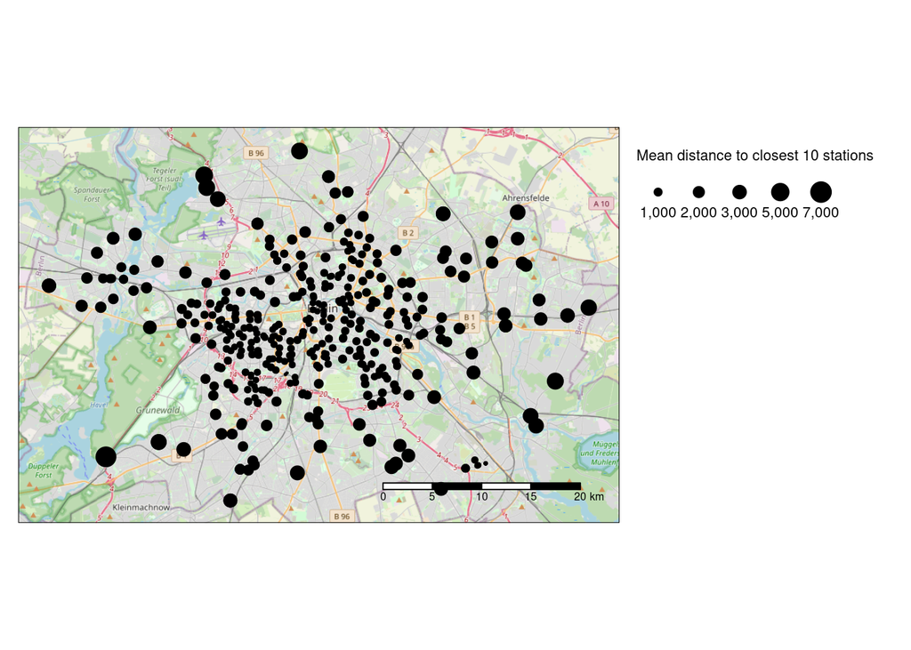

```r
tm_shape(osm_b) + tm_rgb() + tm_shape(charging_stationsB) + tm_dots(size="meanDist10", legend.size.show = TRUE, title.size = "Mean distance to closest 10 stations" ) + tm_basemap(server= "OpenStreetMap.DE") + tm_layout(legend.outside=TRUE) + tm_scale_bar()
```

We see that distances are (not unexpectedly increaing from the city center).

A convenient and fast imlementations is *kNNdist* from the *dbscan* package:

```r
nn4Mat <- kNNdist(st_coordinates(charging_stationsB), k=4, all=TRUE)
head(nn4Mat)
```

```
##          1         2        3        4
## 1   0.0000  94.39053 422.7904 427.1573
## 2   0.0000  94.39053 422.7904 427.1573
## 3   0.0000 266.16057 330.6558 766.6068
## 4 209.5521 565.63630 656.6839 852.1462
## 5 362.3375 565.63630 750.6605 808.8525
## 6 330.6558 330.65578 340.0982 586.6176
```

It returns the distance matrix for the *k* nearest neighbors.

## 2.3 Identify spatial clusters using dbscan

DBSCAN estimates the density around each data point by counting the number of points in a user-specified eps-neighborhood and applies a used-specified minPts thresholds to identify core, border and noise points. In a second step, core points are joined into a cluster if they are density-reachable (i.e., there is a chain of core points where one falls inside the eps-neighborhood of the next). Finally, border points are assigned to clusters. The algorithm only needs parameters eps and minPts.

```r
db_B <- dbscan(st_coordinates(charging_stationsB), eps = 650, minPts = 7)
print(db_B)
```

```
## DBSCAN clustering for 486 objects.
## Parameters: eps = 650, minPts = 7
## The clustering contains 12 cluster(s) and 268 noise points.
##
##   0   1   2   3   4   5   6   7   8   9  10  11  12
## 268  17  25  11   7  10  77  11   8  16  17   7  12
##
## Available fields: cluster, eps, minPts
```

```r
charging_stationsB['dbCluster'] <- db_B$cluster
nClust <- length(unique(db_B$cluster))
```

Define our own palette based on the *Set3* palette but uses white for the noise points.

```r
mypal <- RColorBrewer::brewer.pal(nClust-1, "Set3")
mypal <- c("#FFFFFF", mypal)
```

```r
tmap_mode("view")
```

```
## tmap mode set to interactive viewing
```

```r
tm_shape(charging_stationsB) +
  tm_dots(col = "dbCluster", size=0.25, alpha=.5, palette=mypal, n=nClust) +
  tm_basemap(server= c("OpenStreetMap.DE", "Esri.WorldImagery")) +
  tm_scale_bar()
```

[interactive chart not shown]